# 39_Project1

Tilak Poudel

2025-03-09

## Session 1 & 2

Example_1 Column vector

```r
data<-c(1,2,3,4,5,6,7,8,9)
data
```

```
## [1] 1 2 3 4 5 6 7 8 9
```

```r
text<-c("a","b","c","d","e","f","g","h","i")
text
```

```
## [1] "a" "b" "c" "d" "e" "f" "g" "h" "i"
```

```r
data2<-cbind(data,text)
data2
```

```
##       data text
##  [1,] "1"  "a"
##  [2,] "2"  "b"
##  [3,] "3"  "c"
##  [4,] "4"  "d"
##  [5,] "5"  "e"
##  [6,] "6"  "f"
##  [7,] "7"  "g"
##  [8,] "8"  "h"
##  [9,] "9"  "i"
```

Example_2

Matrix contains in 2 dimensions in table like structure

```r
M<-matrix(
  c(1:9), nrow = 3, ncol = 3, byrow = TRUE
)
print(M)
```

```
##      [,1] [,2] [,3]
## [1,]    1    2    3
## [2,]    4    5    6
## [3,]    7    8    9
```

Example_3

```r
V<-c(1:12)
MDA<-array(V,dim = c(2,3,2))
print(MDA)
```

```
## , , 1
##
##      [,1] [,2] [,3]
## [1,]    1    3    5
## [2,]    2    4    6
##
## , , 2
##
##      [,1] [,2] [,3]
## [1,]    7    9   11
## [2,]    8   10   12
```

## Data frames in R

### Creating data frame in R.

```r
df <- data.frame(x=c(1,2,3), y=c(10,20,30), z=c(30,45,50))
df
```

```
##   x  y  z
## 1 1 10 30
## 2 2 20 45
## 3 3 30 50
```

```r
class(df)
```

```
## [1] "data.frame"
```

Create a data frame

```r
emp.data <- data.frame(
  emp_id = c(1:5),
  emp_name =c("Rick", "Dan", "Michelle", "Ryan", "Gary"),
  salary = c(623.3, 515.2, 611.0, 729.0, 845.25),
  start_date = as.Date(c("2012-01-01", "2013-09-23", "2014-11-15", "2014-05-11", "2015-03-27")),
  stringsAsFactors = FALSE
)

# print the data
print(emp.data)
```

```
##   emp_id emp_name salary start_date
## 1      1     Rick 623.30 2012-01-01
## 2      2      Dan 515.20 2013-09-23
## 3      3 Michelle 611.00 2014-11-15
## 4      4     Ryan 729.00 2014-05-11
## 5      5     Gary 845.25 2015-03-27
```

```r
# Get the structure of the data frame.
str(emp.data)
```

```
## 'data.frame':    5 obs. of  4 variables:
##  $ emp_id    : int  1 2 3 4 5
##  $ emp_name  : chr  "Rick" "Dan" "Michelle" "Ryan" ...
##  $ salary    : num  623 515 611 729 845
##  $ start_date: Date, format: "2012-01-01" "2013-09-23" ...
```

```r
# Print the summary
print(summary(emp.data))
```

```
##      emp_id    emp_name             salary        start_date
##  Min.   :1   Length:5           Min.   :515.2   Min.   :2012-01-01
##  1st Qu.:2   Class :character   1st Qu.:611.0   1st Qu.:2013-09-23
##  Median :3   Mode  :character   Median :623.3   Median :2014-05-11
##  Mean   :3                      Mean   :664.8   Mean   :2014-01-14
##  3rd Qu.:4                      3rd Qu.:729.0   3rd Qu.:2014-11-15
##  Max.   :5                      Max.   :845.2   Max.   :2015-03-27
```

```r
# Extract part of data from data frame
# Extract emp_name and salary
result <- data.frame(emp.data$emp_name, emp.data$salary)
print(result)
```

```
##   emp.data.emp_name emp.data.salary
## 1              Rick          623.30
## 2               Dan          515.20
## 3          Michelle          611.00
## 4              Ryan          729.00
## 5              Gary          845.25
```

```r
# Extract first two rows
result1 <- emp.data[1:2, ]
print(result1)
```

```
##   emp_id emp_name salary start_date
## 1      1     Rick  623.3 2012-01-01
## 2      2      Dan  515.2 2013-09-23
```

```r
# Extract 3rd and 5th row with 2nd and 4th column
result <- emp.data[c(3,5), c(2,4)]
print(result)
```

```
##   emp_name start_date
## 3 Michelle 2014-11-15
## 5     Gary 2015-03-27
```

```r
# Add new column in existing data frame
# Add "dept" column
emp.data$dept <- c("IT", "HR", "Finance", "Operations", "IT")
v <- emp.data

print(v)
```

```
##   emp_id emp_name salary start_date       dept
## 1      1     Rick 623.30 2012-01-01         IT
## 2      2      Dan 515.20 2013-09-23         HR
## 3      3 Michelle 611.00 2014-11-15    Finance
## 4      4     Ryan 729.00 2014-05-11 Operations
## 5      5     Gary 845.25 2015-03-27         IT
```

```r
# Expand data frame in R (Adding cases)
# Create a new data frame
emp.newdata <- data.frame(
  emp_id = c(6:8),
  emp_name =c("Ram", "Shyam", "Mohan"),
  salary = c(923.3, 715.2, 681.0),
  start_date = as.Date(c("2014-01-01", "2013-07-20", "2014-11-25")),
  dept = c("HR", "IT", "Finance"),
  stringsAsFactors = FALSE
)

print(emp.newdata)
```

```
##   emp_id emp_name salary start_date    dept
## 1      6      Ram  923.3 2014-01-01      HR
## 2      7    Shyam  715.2 2013-07-20      IT
## 3      8    Mohan  681.0 2014-11-25 Finance
```

```r
# Expand(Combine) data frame using rbind
# Bind the tow data frames
emp.finaldata <- rbind(emp.data, emp.newdata)
print(emp.finaldata)
```

```
##   emp_id emp_name salary start_date       dept
## 1      1     Rick 623.30 2012-01-01         IT
## 2      2      Dan 515.20 2013-09-23         HR
## 3      3 Michelle 611.00 2014-11-15    Finance
## 4      4     Ryan 729.00 2014-05-11 Operations
## 5      5     Gary 845.25 2015-03-27         IT
## 6      6      Ram 923.30 2014-01-01         HR
## 7      7    Shyam 715.20 2013-07-20         IT
## 8      8    Mohan 681.00 2014-11-25    Finance
```

## Import data in R

```r
# load necessary libraries
library(magrittr)

# Read csv file
covid_nep_data = read.csv('../data/covnep_252days.csv')

print(str(covid_nep_data))
```

```
## 'data.frame':    252 obs. of  7 variables:
##  $ date           : chr  "1/23/2020" "1/24/2020" "1/25/2020" "1/26/2020" ...
##  $ totalCases     : int  1 0 0 0 0 0 0 0 0 0 ...
##  $ newCases       : int  1 0 0 0 0 0 0 0 0 0 ...
##  $ totalRecoveries: int  0 0 0 0 0 0 0 0 1 1 ...
##  $ newRecoveries  : int  0 0 0 0 0 0 0 0 1 0 ...
##  $ totalDeaths    : int  0 0 0 0 0 0 0 0 0 0 ...
##  $ newDeaths      : int  0 0 0 0 0 0 0 0 0 0 ...
## NULL
```

```r
print(head(covid_nep_data))
```

```
##        date totalCases newCases totalRecoveries newRecoveries totalDeaths
## 1 1/23/2020          1        1               0             0           0
## 2 1/24/2020          0        0               0             0           0
## 3 1/25/2020          0        0               0             0           0
## 4 1/26/2020          0        0               0             0           0
## 5 1/27/2020          0        0               0             0           0
## 6 1/28/2020          0        0               0             0           0
##   newDeaths
## 1         0
## 2         0
## 3         0
## 4         0
## 5         0
## 6         0
```

```r
print(summary(covid_nep_data))
```

```
##      date             totalCases       newCases      totalRecoveries
##  Length:252         Min.   :    0   Min.   :   0.0   Min.   :    0
##  Class :character   1st Qu.:    2   1st Qu.:   0.0   1st Qu.:    2
##  Mode  :character   Median :  963   Median :  82.5   Median :  182
##                     Mean   :13376   Mean   : 308.8   Mean   : 8380
##                     3rd Qu.:19340   3rd Qu.: 463.2   3rd Qu.:13932
##                     Max.   :77816   Max.   :2020.0   Max.   :56282
##  newRecoveries     totalDeaths       newDeaths
##  Min.   :   0.0   Min.   :  0.00   Min.   : 0.000
##  1st Qu.:   0.0   1st Qu.:  0.00   1st Qu.: 0.000
##  Median :   3.5   Median :  6.00   Median : 0.000
##  Mean   : 223.3   Mean   : 66.67   Mean   : 1.976
##  3rd Qu.: 197.2   3rd Qu.: 53.75   3rd Qu.: 2.000
##  Max.   :2287.0   Max.   :498.00   Max.   :16.000
```

Importing COVID data in Text Files

```r
y<-read.csv("../data/covnep_252days.csv")
head(y)
```

```
##        date totalCases newCases totalRecoveries newRecoveries totalDeaths
## 1 1/23/2020          1        1               0             0           0
## 2 1/24/2020          0        0               0             0           0
## 3 1/25/2020          0        0               0             0           0
## 4 1/26/2020          0        0               0             0           0
## 5 1/27/2020          0        0               0             0           0
## 6 1/28/2020          0        0               0             0           0
##   newDeaths
## 1         0
## 2         0
## 3         0
## 4         0
## 5         0
## 6         0
```

Importing data into Excel files

```r
library(readxl)
covid_data_xls <- readxl::read_excel("../data/covnep_252days.xlsx")
tail(covid_data_xls)
```

```
## # A tibble: 6 × 7
##   date   totalCases newCases totalRecoveries newRecoveries totalDeaths newDeaths
##   <chr>       <dbl>    <dbl>           <dbl>         <dbl>       <dbl>     <dbl>
## 1 9/25/…      70613     1313           51720          1455         458         6
## 2 9/26/…      71820     1207           52867          1147         466         8
## 3 9/27/…      73393     1573           53752           885         476        10
## 4 9/28/…      74744     1351           54494           742         481         5
## 5 9/29/…      76257     1513           55225           731         491        10
## 6 9/30/…      77816     1559           56282          1057         498         7
```

## Session 3

### Basics of R

#### PEMDAS Rule in R

```r
s<-(4+6)^2*5/10+9-1
print(s)
```

```
## [1] 58
```

#### Data types in R

1. Integer data type

```r
x<-c(1,2,3,4,5,6,7,8,9)
class(x)
```

```
## [1] "numeric"
```

```r
y<-c(1L,2L,3L,4L,5L,6L,7L,8L,9L)
print(y)
```

```
## [1] 1 2 3 4 5 6 7 8 9
```

```r
class(y)
```

```
## [1] "integer"
```

R promotes integer to numeric when needed

(Multiplying integer by numeric)

```r
z<-4L*2.8
print(z)
```

```
## [1] 11.2
```

Dividing integer by integer will give numeric

```r
b<-5L/2L
print(b)
```

```
## [1] 2.5
```

Data_Types_In_R 1) Character

```r
x<-"data"
print(x)
```

```
## [1] "data"
```

```r
class(x)
```

```
## [1] "character"
```

2)Factor

```r
y<-factor("data")
print(y)
```

```
## [1] data
## Levels: data
```

```r
class(y)
```

```
## [1] "factor"
```

Factor and attributes in R

```r
gender<-factor(c("male","female","female","male"))
typeof(gender)
```

```
## [1] "integer"
```

```r
attributes(gender)
```

```
## $levels
## [1] "female" "male"
##
## $class
## [1] "factor"
```

```r
unclass(gender)
```

```
## [1] 2 1 1 2
## attr(,"levels")
## [1] "female" "male"
```

Data_Types

Date: To store Date

```r
date1<-as.Date("2025-03-09")
date1
```

```
## [1] "2025-03-09"
```

```r
class(date1)
```

```
## [1] "Date"
```

POSIXct:To store date and time

```r
date2<-as.POSIXct("2025-03-09 12:57")
date2
```

```
## [1] "2025-03-09 12:57:00 +0545"
```

```r
class(date2)
```

```
## [1] "POSIXct" "POSIXt"
```

Logical_Data_Types

```r
x<- 2 == 3
x
```

```
## [1] FALSE
```

```r
2!=3
```

```
## [1] TRUE
```

```r
2<3
```

```
## [1] TRUE
```

```r
2<=3
```

```
## [1] TRUE
```

```r
2>3
```

```
## [1] FALSE
```

```r
2>=3
```

```
## [1] FALSE
```

```r
"data" == "stats"
```

```
## [1] FALSE
```

```r
"data" < "stats"
```

```
## [1] TRUE
```

```r
"hari" == "hare"
```

```
## [1] FALSE
```

#### Vector operation in R(multiplication by a scalar)

```r
x1<-c(1,2,3,4,5,6,7,8,9)
y<-x1*3
y
```

```
## [1]  3  6  9 12 15 18 21 24 27
```

Addition with Scalar

```r
z<-x1+2
z
```

```
## [1]  3  4  5  6  7  8  9 10 11
```

Subtraction With Scalar

```r
d<-x1-2
d
```

```
## [1] -1  0  1  2  3  4  5  6  7
```

Square root

```r
e<-sqrt(x1)
e
```

```
## [1] 1.000000 1.414214 1.732051 2.000000 2.236068 2.449490 2.645751 2.828427
## [9] 3.000000
```

Extending vector operation in R (Two vectors of equal length)

```r
x<-1:10
y<- -5:4
length(x)
```

```
## [1] 10
```

```r
length(y)
```

```
## [1] 10
```

Addition

```r
x+y
```

```
##  [1] -4 -2  0  2  4  6  8 10 12 14
```

Subtraction

```r
x-y
```

```
##  [1] 6 6 6 6 6 6 6 6 6 6
```

Multiplication

```r
x*y
```

```
##  [1] -5 -8 -9 -8 -5  0  7 16 27 40
```

Division

```r
x/y
```

```
##  [1] -0.2 -0.5 -1.0 -2.0 -5.0  Inf  7.0  4.0  3.0  2.5
```

Power

```r
x^y
```

```
##  [1] 1.000000e+00 6.250000e-02 3.703704e-02 6.250000e-02 2.000000e-01
##  [6] 1.000000e+00 7.000000e+00 6.400000e+01 7.290000e+02 1.000000e+04
```

Addition of both length

```r
length(x+y)
```

```
## [1] 10
```

Two vector of unequal length (Addition)

```r
x<-1:10
z<-c(1,2)
x+z
```

```
##  [1]  2  4  4  6  6  8  8 10 10 12
```

Accessing individual elements in R

```r
x[1]
```

```
## [1] 1
```

```r
x[c(1,4)]
```

```
## [1] 1 4
```

Creation and giving name to a Vector

```r
w1<-1:3
names(w1)<-c("a", "b", "c")
w1
```

```
## a b c
## 1 2 3
```

#### Missing data in R (NA Type)

```r
zchar<-c("Hockey", NA, "Cricket")
is.na(zchar)
```

```
## [1] FALSE  TRUE FALSE
```

```r
nchar(zchar)
```

```
## [1]  6 NA  7
```

Calculating mean of missing Data

```r
z<-c(1,2,NA,8,3,NA,3)
mean(z)
```

```
## [1] NA
```

Removing NA and calculating mean

```r
mean(z, na.rm = TRUE)
```

```
## [1] 3.4
```

Calculating variance excluding NA

```r
var(z, na.rm = TRUE)
```

```
## [1] 7.3
```

NULL type missing in R

```r
z<-c(1, NULL, 3)
z
```

```
## [1] 1 3
```

```r
is.null(z)
```

```
## [1] FALSE
```

```r
f<-NULL
is.null(f)
```

```
## [1] TRUE
```

#### Pipes in R

```r
x<-1:10
mean(x)
```

```
## [1] 5.5
```

With pipe operator(%>%)

```r
library(magrittr)
x%>%mean
```

```
## [1] 5.5
```

```r
z<-c(1,2,NA,8,3,NA,3)
sum(is.na(z))
```

```
## [1] 2
```

Pipes without nesting

```r
z %>% is.na %>% sum
```

```
## [1] 2
```

Additional argument

```r
z %>% mean(na.rm = TRUE)
```

```
## [1] 3.4
```

### Advanced Data Structure In R

(Data Frame)

```r
x<-10:1
y<- -4:5
q<-c("Hockey","Football","Baseball","Kabaddi","Rugby","Pingpong","Basketball","Tennis","Cricket","Volleyball")
sportsDF<-data.frame(x,y,q)
sportsDF
```

```
##     x  y          q
## 1  10 -4     Hockey
## 2   9 -3   Football
## 3   8 -2   Baseball
## 4   7 -1    Kabaddi
## 5   6  0      Rugby
## 6   5  1   Pingpong
## 7   4  2 Basketball
## 8   3  3     Tennis
## 9   2  4    Cricket
## 10  1  5 Volleyball
```

Naming data frame

```r
sportsDF<-data.frame(First =x, Second = y, Sport = q)
sportsDF
```

```
##    First Second      Sport
## 1     10     -4     Hockey
## 2      9     -3   Football
## 3      8     -2   Baseball
## 4      7     -1    Kabaddi
## 5      6      0      Rugby
## 6      5      1   Pingpong
## 7      4      2 Basketball
## 8      3      3     Tennis
## 9      2      4    Cricket
## 10     1      5 Volleyball
```

Accessing column

```r
names(sportsDF)[3]
```

```
## [1] "Sport"
```

```r
rownames(sportsDF)
```

```
##  [1] "1"  "2"  "3"  "4"  "5"  "6"  "7"  "8"  "9"  "10"
```

```r
rownames(sportsDF)<-c("One","Two","Three","Four","Five","Six","Seven","Eight","Nine","Ten")
sportsDF
```

```
##       First Second      Sport
## One      10     -4     Hockey
## Two       9     -3   Football
## Three     8     -2   Baseball
## Four      7     -1    Kabaddi
## Five      6      0      Rugby
## Six       5      1   Pingpong
## Seven     4      2 Basketball
## Eight     3      3     Tennis
## Nine      2      4    Cricket
## Ten       1      5 Volleyball
```

Printing first few Rows

```r
head(sportsDF)
```

```
##       First Second    Sport
## One      10     -4   Hockey
## Two       9     -3 Football
## Three     8     -2 Baseball
## Four      7     -1  Kabaddi
## Five      6      0    Rugby
## Six       5      1 Pingpong
```

Printing last few rows

```r
tail(sportsDF)
```

```
##       First Second      Sport
## Five      6      0      Rugby
## Six       5      1   Pingpong
## Seven     4      2 Basketball
## Eight     3      3     Tennis
## Nine      2      4    Cricket
## Ten       1      5 Volleyball
```

Printing first seven rows

```r
head(sportsDF, n =7)
```

```
##       First Second      Sport
## One      10     -4     Hockey
## Two       9     -3   Football
## Three     8     -2   Baseball
## Four      7     -1    Kabaddi
## Five      6      0      Rugby
## Six       5      1   Pingpong
## Seven     4      2 Basketball
```

Accessing value from third row and second column

```r
sportsDF[3,2]
```

```
## [1] -2
```

Accessing from Third column

```r
sportsDF[,3]
```

```
##  [1] "Hockey"     "Football"   "Baseball"   "Kabaddi"    "Rugby"
##  [6] "Pingpong"   "Basketball" "Tennis"     "Cricket"    "Volleyball"
```

```r
sportsDF[,c("First","Sport")]
```

```
##       First      Sport
## One      10     Hockey
## Two       9   Football
## Three     8   Baseball
## Four      7    Kabaddi
## Five      6      Rugby
## Six       5   Pingpong
## Seven     4 Basketball
## Eight     3     Tennis
## Nine      2    Cricket
## Ten       1 Volleyball
```

```r
sportsDF[,"Sport",drop = FALSE]
```

```
##            Sport
## One       Hockey
## Two     Football
## Three   Baseball
## Four     Kabaddi
## Five       Rugby
## Six     Pingpong
## Seven Basketball
## Eight     Tennis
## Nine     Cricket
## Ten   Volleyball
```

#### Lists in R

```r
list1<-list(1,2,3)
list1
```

```
## [[1]]
## [1] 1
##
## [[2]]
## [1] 2
##
## [[3]]
## [1] 3
```

Single element list

```r
list2<-list(c(1,2,3))
list2
```

```
## [[1]]
## [1] 1 2 3
```

```r
list3<-list(c(1,2,3),3:7)
list3
```

```
## [[1]]
## [1] 1 2 3
##
## [[2]]
## [1] 3 4 5 6 7
```

List with data frame and vector

```r
list4<-list(sportsDF,1:10)
list4
```

```
## [[1]]
##       First Second      Sport
## One      10     -4     Hockey
## Two       9     -3   Football
## Three     8     -2   Baseball
## Four      7     -1    Kabaddi
## Five      6      0      Rugby
## Six       5      1   Pingpong
## Seven     4      2 Basketball
## Eight     3      3     Tennis
## Nine      2      4    Cricket
## Ten       1      5 Volleyball
##
## [[2]]
##  [1]  1  2  3  4  5  6  7  8  9 10
```

```r
list5<-list(sportsDF,1:10,list3)
list5
```

```
## [[1]]
##       First Second      Sport
## One      10     -4     Hockey
## Two       9     -3   Football
## Three     8     -2   Baseball
## Four      7     -1    Kabaddi
## Five      6      0      Rugby
## Six       5      1   Pingpong
## Seven     4      2 Basketball
## Eight     3      3     Tennis
## Nine      2      4    Cricket
## Ten       1      5 Volleyball
##
## [[2]]
##  [1]  1  2  3  4  5  6  7  8  9 10
##
## [[3]]
## [[3]][[1]]
## [1] 1 2 3
##
## [[3]][[2]]
## [1] 3 4 5 6 7
```

```r
names(list5)
```

[output not shown]

Naming the first as data frame , second as vector and the third as list

```r
names(list5)<-c("dataframe","vector","list")
list5
```

```
## $dataframe
##       First Second      Sport
## One      10     -4     Hockey
## Two       9     -3   Football
## Three     8     -2   Baseball
## Four      7     -1    Kabaddi
## Five      6      0      Rugby
## Six       5      1   Pingpong
## Seven     4      2 Basketball
## Eight     3      3     Tennis
## Nine      2      4    Cricket
## Ten       1      5 Volleyball
##
## $vector
##  [1]  1  2  3  4  5  6  7  8  9 10
##
## $list
## $list[[1]]
## [1] 1 2 3
##
## $list[[2]]
## [1] 3 4 5 6 7
```

Accessing elements of list It returns the first element i.e data frame

```r
list5[[1]]
```

```
##       First Second      Sport
## One      10     -4     Hockey
## Two       9     -3   Football
## Three     8     -2   Baseball
## Four      7     -1    Kabaddi
## Five      6      0      Rugby
## Six       5      1   Pingpong
## Seven     4      2 Basketball
## Eight     3      3     Tennis
## Nine      2      4    Cricket
## Ten       1      5 Volleyball
```

Alternativley, we can access by its name as well

```r
list5[["dataframe"]]
```

```
##       First Second      Sport
## One      10     -4     Hockey
## Two       9     -3   Football
## Three     8     -2   Baseball
## Four      7     -1    Kabaddi
## Five      6      0      Rugby
## Six       5      1   Pingpong
## Seven     4      2 Basketball
## Eight     3      3     Tennis
## Nine      2      4    Cricket
## Ten       1      5 Volleyball
```

Accessed element manipulation

```r
list5[[1]]$Sport #Sport variable
```

```
##  [1] "Hockey"     "Football"   "Baseball"   "Kabaddi"    "Rugby"
##  [6] "Pingpong"   "Basketball" "Tennis"     "Cricket"    "Volleyball"
```

```r
list5[[1]][, "Second"]
```

```
##  [1] -4 -3 -2 -1  0  1  2  3  4  5
```

```r
list5[[1]][, "Second", drop=F]
```

```
##       Second
## One       -4
## Two       -3
## Three     -2
## Four      -1
## Five       0
## Six        1
## Seven      2
## Eight      3
## Nine       4
## Ten        5
```

```r
length(list5)
```

```
## [1] 3
```

Adding new element

```r
list5[[4]] <- 2
list5[["NewElement"]] <-3:6
print(names(list5))
```

```
## [1] "dataframe"  "vector"     "list"       ""           "NewElement"
```

```r
print(list5)
```

```
## $dataframe
##       First Second      Sport
## One      10     -4     Hockey
## Two       9     -3   Football
## Three     8     -2   Baseball
## Four      7     -1    Kabaddi
## Five      6      0      Rugby
## Six       5      1   Pingpong
## Seven     4      2 Basketball
## Eight     3      3     Tennis
## Nine      2      4    Cricket
## Ten       1      5 Volleyball
##
## $vector
##  [1]  1  2  3  4  5  6  7  8  9 10
##
## $list
## $list[[1]]
## [1] 1 2 3
##
## $list[[2]]
## [1] 3 4 5 6 7
##
##
## [[4]]
## [1] 2
##
## $NewElement
## [1] 3 4 5 6
```

### Matrices in R

Performing matrix operations

```r
A <- matrix(1:10, nrow=5)
B <- matrix(21:30, nrow=5)
C <- matrix(21:40, nrow=2)

row(A)
```

```
##      [,1] [,2]
## [1,]    1    1
## [2,]    2    2
## [3,]    3    3
## [4,]    4    4
## [5,]    5    5
```

```r
ncol(B)
```

```
## [1] 2
```

```r
dim(C)
```

```
## [1]  2 10
```

```r
A + B
```

```
##      [,1] [,2]
## [1,]   22   32
## [2,]   24   34
## [3,]   26   36
## [4,]   28   38
## [5,]   30   40
```

```r
A * B
```

```
##      [,1] [,2]
## [1,]   21  156
## [2,]   44  189
## [3,]   69  224
## [4,]   96  261
## [5,]  125  300
```

```r
A - B
```

```
##      [,1] [,2]
## [1,]  -20  -20
## [2,]  -20  -20
## [3,]  -20  -20
## [4,]  -20  -20
## [5,]  -20  -20
```

```r
A = B
```

### Arrays in R

```r
theArray <- array(1:12, dim=c(2,3,2))
theArray
```

```
## , , 1
##
##      [,1] [,2] [,3]
## [1,]    1    3    5
## [2,]    2    4    6
##
## , , 2
##
##      [,1] [,2] [,3]
## [1,]    7    9   11
## [2,]    8   10   12
```

```r
theArray [1, , ] # 1st row of both
```

```
##      [,1] [,2]
## [1,]    1    7
## [2,]    3    9
## [3,]    5   11
```

```r
theArray[1, ,1] # 1st row of first
```

```
## [1] 1 3 5
```

```r
theArray[,1,] #1st column of both
```

```
##      [,1] [,2]
## [1,]    1    7
## [2,]    2    8
```

## Session 4

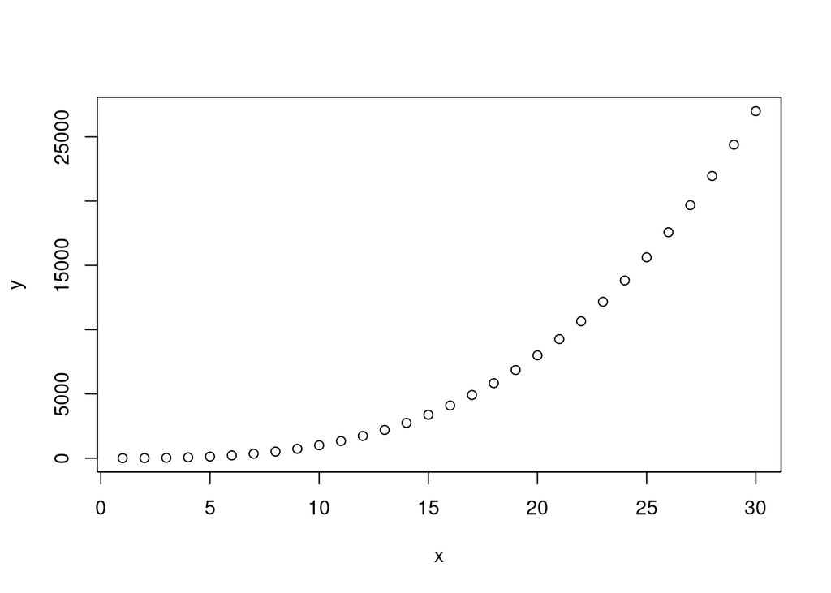

```r
#Column vector
x <- c(1:30)
y <- x^3
plot(x,y)
```

R script examples

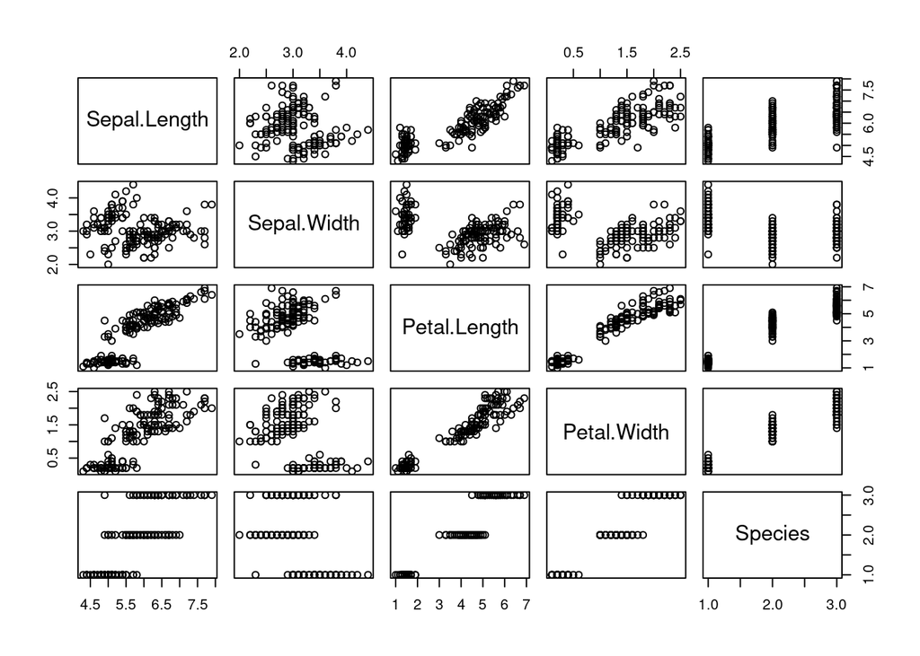

```r
#store the current directory
initial.dir <- getwd()

#change to new directory
setwd("~/projects/tilak/mds1/R-programming")

# load necessary libraries
library(magrittr)

# set the output file (it will bypass R and Rstudio)
sink("result.out")

# load the data set from the folder
iris <- read.csv("data/iris-data.csv")
colnames(iris)

# Do the analysis
plot(iris)
```

```r
# result will appear in the output file
summary(iris)
cor(iris$Sepal.Length, iris$Sepal.Width)

#Close the output file
sink()

# unload the libraries
detach("package:magrittr")

# change back to original directory
setwd(initial.dir)
```

### Tee Operator

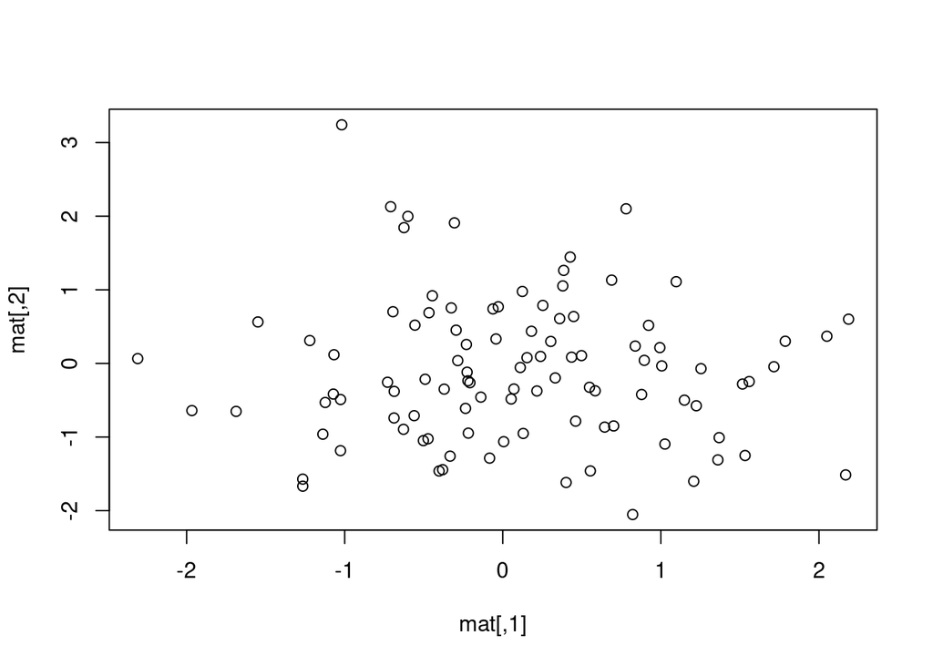

```r
# load necessary libraries
library(magrittr)

set.seed(123)
# set 200 random normal distribution data
mat <- rnorm(200) %>% matrix(ncol = 2)

# Plot the matrix
plot(mat)
```

```r
# Compute column sums separately
colSums(mat)
```

```
## [1]   9.040591 -10.754680
```

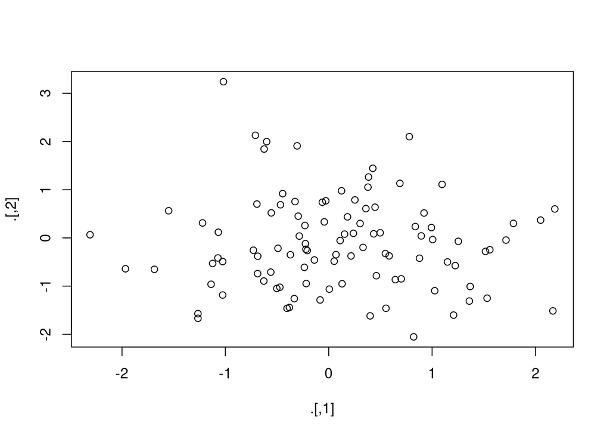

```
## [1]   9.040591 -10.754680
```

```r
# use of tee pipe operator
set.seed(123)
# set 200 random normal distribution data
rnorm(200) %>%
  matrix(ncol = 2) %T>%
  plot %>%
  colSums
```